# Supplement 1 - Simulating a coin flip and a dice roll

To demonstrate how probability can be interpreted as a long-run relative frequency let's start by simulating an increasing number of coin flips. Let's assume a perfect flip and simulate 10,000 flips by sampling from a set space $S=\{0,1\}$, where 0 represents heads and 1 represents tails.

```r
flips <- sample(0:1, 10000, replace=TRUE)
```

We have created a vector using the sample function, the first argument tells the function the range of integers from which to sample from, the second argument is the number of samples and the replace=TRUE option allows for repeated values.

Let's look at a histogram from the first 10 values of the vector, this is akin to have flipped the coin 10 times.

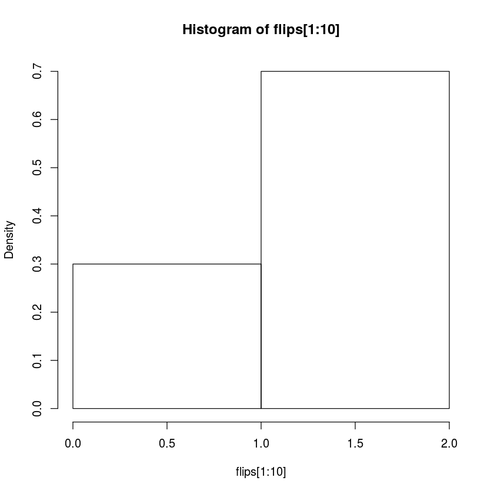

```r
hist(flips[1:10], breaks=c(0,1,2), freq=FALSE, right=FALSE)
```

This are obviously not the expected probabilities for a fair dice, i. e., $P(0) = P(1) = 0.5$, let's see what's happens if we increase the number of flips.

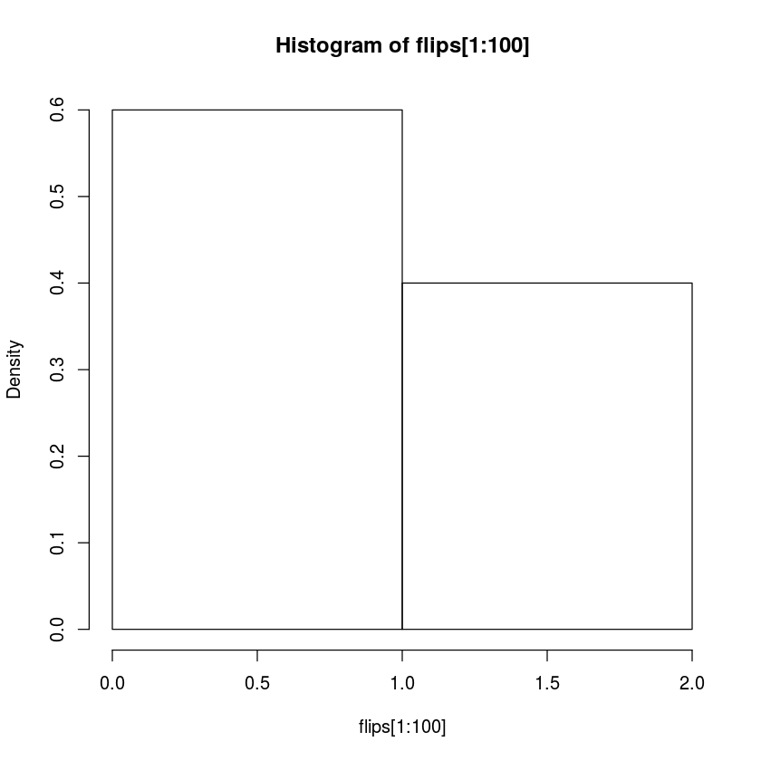

```r
hist(flips[1:100], breaks=c(0,1,2), freq=FALSE, right=FALSE)
```

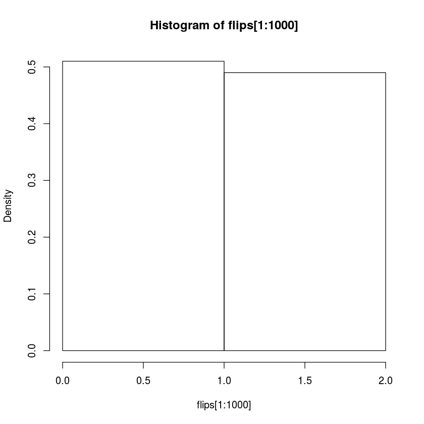

```r
hist(flips[1:1000], breaks=c(0,1,2), freq=FALSE, right=FALSE)
```

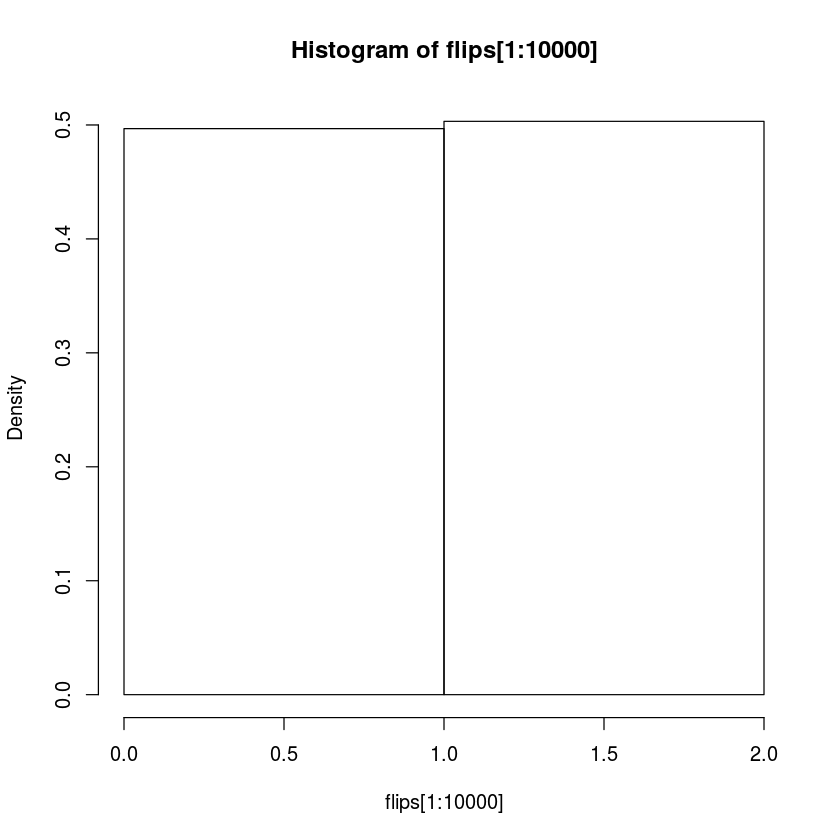

```r
hist(flips[1:10000], breaks=c(0,1,2), freq=FALSE, right=FALSE)
```

Now we are getting close to the expected probabilities. In the limit $n\rightarrow \infty$ the probabilities are exactly $0.5$.

We can do the same for a dice, but we now sample for the first 6 integers.

```r
rolls <- sample(1:6, 10000, replace=TRUE)
```

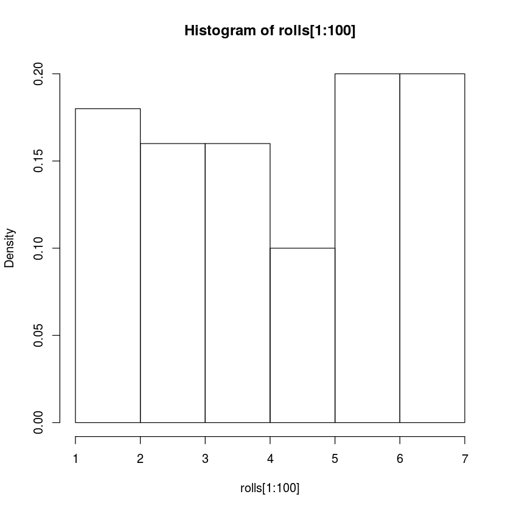

```r
hist(rolls[1:100], breaks=c(1, 2, 3, 4, 5, 6,7), freq=FALSE, right=FALSE)
```

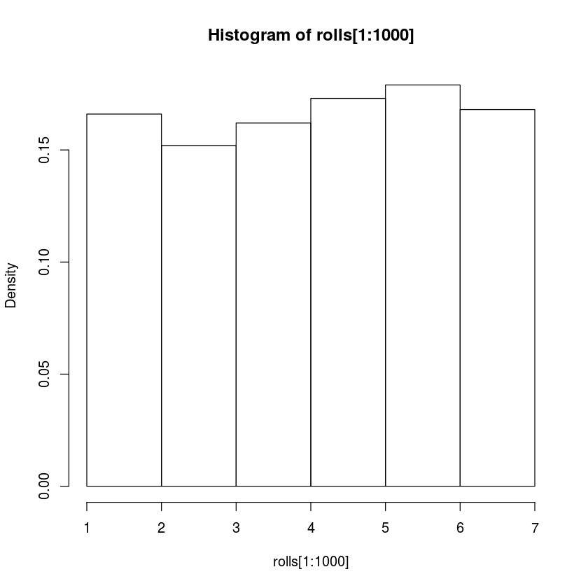

```r
hist(rolls[1:1000], breaks=c(1, 2, 3, 4, 5, 6,7), freq=FALSE, right=FALSE)
```

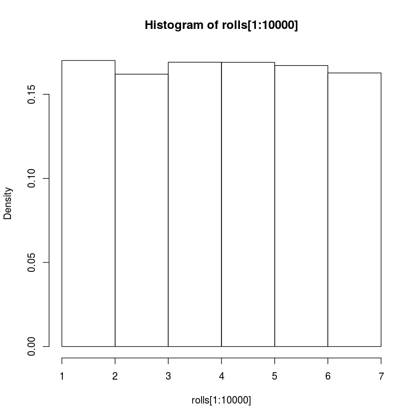

```r
hist(rolls[1:10000], breaks=c(1, 2, 3, 4, 5, 6,7), freq=FALSE, right=FALSE)
```

Again, as $n\rightarrow\infty$ the probabilities approach the expected probabilities of a fair dice, $P(1)=P(2)=P(3)=P(4)=P(5)=P(6)=1/6\approx 0.167$.